# Investments

Week 1 – Lecture  
Utz Weitzel – VU Finance

# 1st steps in R

## Prepare session

Please make sure you have the most recent and updated version of R and RStudio installed.

In RStudio, open a project, or make a new one.

If you haven’t done so already, install the tidyverse package

```
install.packages("tidyverse") # once per machine
```

Then load the package

```r
library(tidyverse) # at the start of every session
```

.

.

.

.

.

## Import data

Copy the data file to the project folder first.

Then import as dataframe

```r
df101 = read_csv("df101.csv")   # many use <- for =
```

You can also choose other names for the dataframe, but for this session let’s stick to `df101`.

Apple users seem to experience some issues when loading the data. The data on Canvas are now in UTF-8 format (please download again), and see the lecture slides for ChatGPT ticks and tips and a cloud based RStudio alternative. Also, make sure you download the data from canvas in Google Chrome, not Safari, as the latter seems to save the csv data in a less compatible way.

.

.

.

## Explore data

Now we can view the data and their structure in the RStudio environment, or like this

```r
View(df101) # also table icon in environment (capital 'V'!)
str(df101)  # also dropdown icon in environment
```

There are more ways to explore the data.

*Try this yourself*

```r
summary(df101)          # summary stats
distinct(df101,ticker)  # show unique tickernames
head(df101)             # top section
tail(df101)             # bottom section
glimpse(df101)          # data structure
colnames(df101)         # show variable names
```

.

.

.

## Subset data

Let’s make a new dataframe with

- the observations for Apple in the last quarter of 2023 (‘filter’ rows)
- and specific variables (‘select’ columns)

```r
dfa = df101 |>                # many use %>% as 'Pipe Operator'
  filter(ticker == "AAPL") |>
  filter(date >= "2023-10-01" & date <= "2023-12-31") |>
  select(date, year, month, close, ret) |>
  arrange(date)               # or, arrange(desc(date))

View(dfa)
```

.

.

.

## HPR adj

In `dfa`, `ret` refers to daily returns that are *adjusted* for *stock splits* and for *dividends*. For the *adjusted HPR*, `hpr_adj`, we compound the daily returns as follows

```r
dfa1 = dfa |>
  mutate(hpr_adj = prod(1+ret) - 1)       # mutates a (new) var

View(dfa1)
```

`prod()` multiplies all values in column `ret` (after adding a 1), but does not like missing values. So, if you are not sure, set `na.rm=TRUE`.

```r
dfa1 = dfa |>
  mutate(hpr_adj = prod(1+ret, na.rm=TRUE) - 1)   # or na.rm=T
```

.

.

## HPR adj (DIY)

You can also mutate step by step

*Try this yourself*

```r
dfa2 = dfa |>
  mutate(ret1 = 1+ret) |>
  mutate(prodret = prod(ret1, na.rm=T)) |>
  mutate(hpr_adj = prodret-1)

View(dfa2)
```

The code is a bit more tedious, but good for eyeballing each step in `dfa2`.

.

.

.

.

## Monthly ret

The monthly return is the HPR per month. We use

- `group_by` to group the data by year-month, and
- `summarize` to create a new variable `hpr` with compounded daily returns by month

```r
dfa3 = dfa |>
  group_by(month, year) |>
  summarize(hpr  = prod(1+ret, na.rm=T)-1,
            #
            # let's add more vars...
            tday = n()) # alternatively: tday=length(ret)

View(dfa3)
```

Note that we `summarize` to rows at the level of `group_by`. In this process you can create more new variables, like `tday`, the number of trading days per month.

.

.

.

.

## Monthly ret (DIY)

You can also create (duplicated) monthly values at the daily level:

- use `mutate` (instead of `summarize`) to create a new variable `hpr_mth` at the daily level
- optional: use `dfa = dfa` if you want to add `hpr_mth` to the original dataframe

*Try this yourself*

```r
dfa = dfa |>
  group_by(year, month) |>
  mutate(hpr_mth = prod(1+ret, na.rm=T)-1) |>
  arrange(year, month)

View(dfa)
```

.

.

## Vectors (DIY)

We mainly looked at panel dataframes with several variables (columns) and observations (rows). But dataframes can also be a vector of one variable with observations

```r
ticklist = df101 |>
  select(ticker) |>   # single column (duplicates in rows)
  distinct()          # optional: extract unique values

View(ticklist)
```

Or a vector with just one observation

```r
medret = dfa |>                        # Apple data
  select(ret) |>                       # all returns of Apple
  filter(ret == median(ret, na.rm=T))  # row with median return

View(medret)
```

.

.

## Values (DIY)

It’s not handy to store a single value in a dataframe. So, lets convert `medret`

```r
medret_a = as.double(medret)  # try other formats: as.float,as.integer,...

print(medret_a)               # or type medret_a in console + Enter
```

Do you find `medret_a` in the RStudio environment? Yes, it is listed under ‘Values’ beneath ‘Data’.

.

.

.

.

.

.

.

## Direct access (DIY)

We can also get the median return of a column without `select` and `filter`. Simply access the column `ret` in the dataframe `dfa` directly with `dfa$ret` and take the median

```r
medret_a2 = median(dfa$ret, na.rm=T)
```

Or we get the value of the median return for Microsoft in the original dataframe `df101`, … or add a vector with logarithmic returns in dataframe `dfa`

```r
medret_m2 = median(subset(df101$ret, df101$ticker == "MSFT"), na.rm = TRUE)

dfa$log_ret = log(1+dfa$ret)
```

**Note**

Once you get used to accessing vectors in dataframes directly with `dataframe$variable`, you can easily jump between dataframes and compute variables more flexibly than with the piping operator `|>`. But, beware, it can also quickly become more messy.

.

.

## HPR price (DIY)

We computed `HPR_adj` based on returns, but sometimes you want to compute HPRs based on prices. Let’s use our new skills and find the closing prices in `dfa` at the start and end of the total period

```r
date_start = min(dfa$date, na.rm=T)
date_end   = max(dfa$date, na.rm=T)

cls_start  = subset(dfa$close, dfa$date == date_start)
cls_end    = subset(dfa$close, dfa$date == date_end)

hpr_cls = cls_end/cls_start - 1

print(hpr_cls)
print(unique(dfa1$hpr_adj))
```

Why is `hpr_cls` not equal to `hpr_adj` in `dfa1`?

**Tip**

Recall that `ret` is adjusted for stock splits and dividends. The closing price is not.

.

.

.

.

# Risk & Return

For this section, we import dataset `df102` with *monthly* data for: equity returns `re`, [four-week T-bill discounts](https://fred.stlouisfed.org/series/DTB4WK) `tbill`, and [five-year TIPS bond yields](https://fred.stlouisfed.org/series/DFII5) `tips`

```r
df102 = read_csv("df102.csv", show_col_types=FALSE)
```

**Important**

Don’t forget to copy the file from Canvas to your project folder first.

Take a look

```r
summary(df102)
distinct(df102,ticker)
View(df102)
```

.

.

.

## Excess return rx

```r
dfrx1 = df102 |> mutate(rx = re-tbill)

View(dfrx1)
```

and compounded over the whole sample period of 10 years

```r
dfrx2 = df102 |>
  group_by(ticker) |>
  summarize(rx = prod(1 + re-tbill, na.rm=T)-1)

View(dfrx2)
```

Recall that `rx` is in decimals! Supposedly, Einstein called compounding the 8th world wonder.

.

## Forecast rx (DIY)

It is Jan 1, 2024 and we want to invest in MSFT for the next 5 years (buy and hold).

- We believe MSFT’s average monthly excess return `rx` in the past 10 years (sample period) is the best forecast for the next 5 years.
- The maturity of `rf` should match the investment horizon: we take the yield of the 5-year `tips` (quoted monthly) as the expected real `rf`.

What is our expected compounded excess return `rx_cmp` in 5 years (60 months)?

```r
dfrx3 = df102 |> filter(ticker=="MSFT") |>
    mutate(rx = re - tips) |>
    summarize(n        = n(),
              rx_geom  = prod(1+rx)^(1/n) - 1,
              rx_arthm = mean(rx)) |>
    mutate(rx_mth      = rx_geom*60/n + rx_arthm*(n-60)/n) |>
    mutate(rx_cmp      = (1+rx_mth)^60 - 1)
```

.

.

## Sharpe

We compute the ex post Sharpe ratio with all monthly excess returns in the sample. The resulting return-over-risk ratio therefore refers to one (average) month.

Financial analysts [typically annualize](https://awgmain.morningstar.com/webhelp/glossary_definitions/mutual_fund/mfglossary_Sharpe_Ratio.html) monthly or daily Sharpe ratios by multiplying them with the square root of 12 (months) or 252 (trading days), respectively. This assumes [serially uncorrelated](https://doi.org/10.2469/faj.v58.n4.2453) returns!

```r
dfshrp = df102 |>
  mutate(rx = re-tbill) |>  # tbill, not tips
  group_by(ticker) |>
  summarize(sharpe_mth = mean(rx)/sd(rx)) |>
  mutate(sharpe_yr     = sharpe_mth * 12^(1/2))

View(dfshrp)
```

.

.

.

## Sortino

**Denominator**: for the Lower Partial Standard Deviation (LPSD) we only consider negative excess returns `rx<0` (that is, `re` lies below `rf=tbill` or any other target return).

**Numerator**: for the mean excess return we use the entire sample of observations.

```r
dfsorti = df102 |>
  mutate(rx = re-tbill) |>
  mutate(rx_lp = if_else(rx<0, rx, NA_real_)) |> # replace rx>=0 with NA
  group_by(ticker) |>
  summarize(sorti_mth = mean(rx, na.rm=T)/sd(rx_lp, na.rm=T),
            #
            # let's also count the obs that enter LPSD
            n_lpsd = sum(!is.na(rx_lp)))

View(dfsorti)
```

Note that positive values of `rx` are not set to zero, but to ‘missing’ (with `NA_real_`). It is therefore important to use `na.rm=T` in `sd()`.

.

## VaR normal

If returns are **normally distributed**, we use the *mean* and *sd* of `re` to compute the quantile value of the corresponding standard normal distribution. Assume an investment of 22000 US$.

For monthly returns, the VaR95 is

```r
Invest = 22000

dfVaRn = df102 |>
  group_by(ticker) |>
  summarize(re_av = mean(re, na.rm=T),
            re_sd = sd(re, na.rm=T)) |>
  mutate(VaR95nrm_pct = qnorm(0.05, re_av, re_sd)*-100) |>
  mutate(VaR95nrm_inv = qnorm(0.05, re_av, re_sd)*-Invest)

View(dfVaRn)
print(qnorm(0.05)) # quantile value of standard normal distribution
```

DIY: Check by applying the quantile value of `qnorm(0.05)` to the values in `dfVaRn`: compute `re_av-1.6448*re_sd` and then multiply by `-100` (for VaR95 in percent) or `-Invest` (for VaR95 as a dollar loss).

.

.

## VaR direct

If returns are **not** **normally distributed**, we can compute the monthly VaR95 directly, by finding the value of the 5th percentile of the sample distribution of `re`.

```r
Invest = 22000

dfVaRd = df102 |>
  group_by(ticker) |>
  summarize(VaR95dir_pct = quantile(re, probs=0.05)*-100,
            VaR95dir_inv = quantile(re, probs=0.05)*-Invest,
            #
            # Let's add the VaR-normal for comparison
            re_av = mean(re, na.rm=T),
            re_sd = sd(re, na.rm=T)) |>
  mutate(VaR95nrm_pct = qnorm(0.05, re_av, re_sd)*-100)

View(dfVaRd)
```

.

.

.

.

## ES

For the monthly 5% expected shortfall (ES), we compute the 5% quantile value (similar to VaR95, but negative and not % or $) and take the average of all values below this cut-off.

```r
dfes = df102 |>
  group_by(ticker) |>
  mutate(cutoff = quantile(re, probs=0.05)) |>
  mutate(sub_cut = ifelse(re < cutoff, re, NA_real_)) |>
  summarize(ES5  = mean(sub_cut, na.rm=T),
            #
            # let's count the obs that enter ES5
            n_ES5 = sum(!is.na(sub_cut)))

View(dfes)
```

**Note**

Some terms are tossed around more than a Frisbee on a hot summer day. ES is also called conditional tail expectation (CTE), conditional VaR (CVaR), average VaR (AVaR), expected tail loss (ETL), and superquantile.

.

.

## Neg 3-Sigma

Count the cases below the negative 3 sigma return and divide them by the number of cases that would be expected in a normal distribution.

```r
dfn3s = df102 |> group_by(ticker) |>
  mutate(re_av = mean(re, na.rm=T)) |>
  mutate(re_sd = sd(re, na.rm=T)) |>
  mutate(re_n3 = re_av-3*re_sd) |>
  mutate(sub   = ifelse(re<re_n3, re, NA_real_)) |>
  arrange(sub) # just curious
View(dfn3s)    # ... Burgers & Coke in 03/2020, rings a bell?
```

```r
dfn4s = dfn3s |> group_by(ticker) |> # continue with dfn3s
  summarize(N = n(),
            n_sub = sum(!is.na(sub))) |>
  mutate(p_sub = n_sub/N) |>
  mutate(p_exp = pnorm(-3, mean=0, sd=1, lower.tail=T)) |> # or: pnorm(-3)
  mutate(n3s   = p_sub/p_exp)
View(dfn4s)
```

.

# Capital Allocation

Let’s take a look at the simplest of all portfolios: a mix of one risky asset and one risk-free asset. We set out to find the **complete portfolio** as a solution to the trade-off between a risky `stock` and a risk-free `tbill`.

```r
df102 = read_csv("df102.csv", show_col_types=FALSE)

dfcp = df102 |>
  filter(ticker=="AAPL") |>
  select(date, re, tbill)

colnames(dfcp) = c("date" ,"re", "rf")

View(dfcp)
```

.

.

.

.

## Risky & Risk-free

To compute the *annualized* expected returns and volatility for the two assets `stock` and `tbill`, we use monthly excess returns `re-rf` to compute annualized `rx_exp` and `rx_sd`.

```r
rx_exp = (1+mean(dfcp$re-dfcp$rf, na.rm=T))^12 -1 # stock: exp ret
rf_exp = (1+mean(dfcp$rf, na.rm=T))^12 -1         # tbill: exp ret

rx_sd  = sd(dfcp$re-dfcp$rf, na.rm=T) * sqrt(12)  # stock: exp sd
rf_sd  = 0                                        # tbill: exp sd

sharpe = rx_exp/rx_sd                             # reward to risk
```

**Note**

Note that we assume a volatility of zero for `rf` (although the historic returns of the `tbill` are not constant). This is because we argue (a) in terms of excess returns where `rf` is already part of `rx`, and (b) in expected terms, which conveniently assume `rf_sd=0` to simplify life.

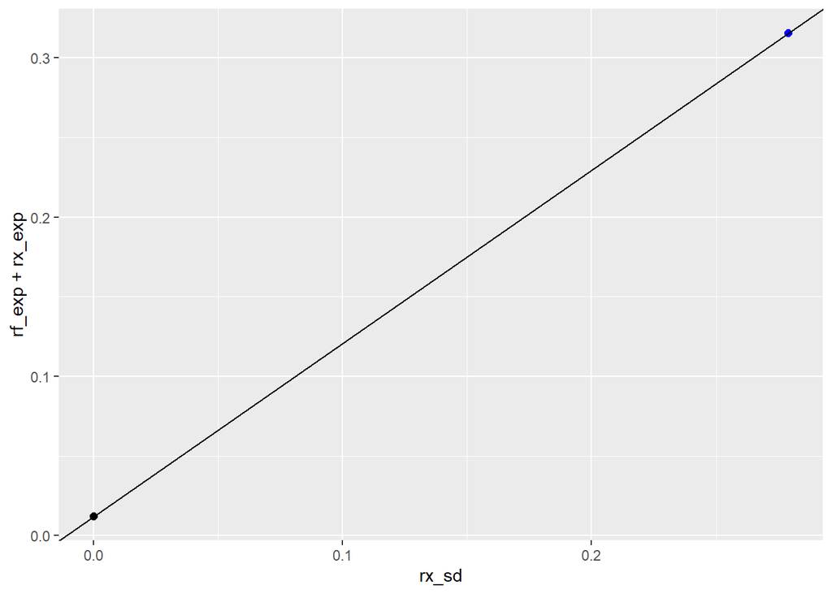

```r
plot_dfcp = ggplot() +
  geom_point(aes(x=rx_sd, y=rf_exp+rx_exp), color = "blue", size = 2) +
  geom_point(aes(x=rf_sd, y=rf_exp), color = "black", size = 2) +
  geom_abline(intercept=rf_exp, slope=sharpe)+
  labs(x="rx_sd", y="rf_exp + rx_exp")

print(plot_dfcp)
```

.

.

## Utility score

Compute the utility score for the two extreme portfolios `stock` and `tbill` and some mixed portfolios in between (with a share of `y` in `stock` and `1-y` in `tbill`). Assume a risk aversion parameter of `A=6`.

```r
dfutil = data.frame(y = 0:10 / 10) |>
  mutate(A        = 6) |>
  mutate(ret_port = rf_exp + y*rx_exp) |>       # note: rx=re-rf
  mutate(rsk_port = y^2 * rx_sd^2) |>           # note: variance
  mutate(uscore   = ret_port - 0.5*A*rsk_port)

View(dfutil)
```

**Caution**

The expected utility equation is tricky because it contains absolute values. For example, the value of 0.5 in the utility equation is based on the assumption that expected return and variance are expressed as decimals. If those quantities were expressed as percentage, the 0.5 would change to 0.005. Also, all risk and return values must be annualized!

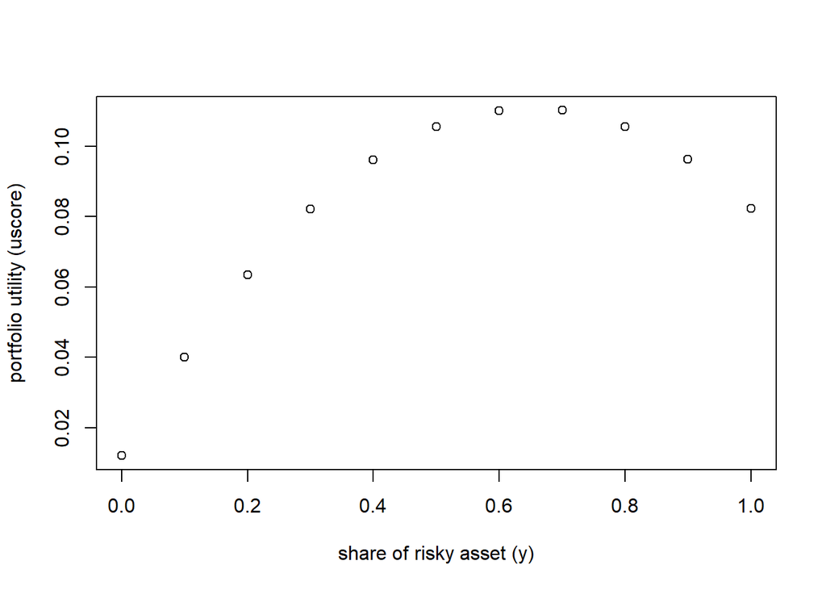

```r
plot(dfutil$y, dfutil$uscore,
     xlab = "share of risky asset (y)",
     ylab = "portfolio utility (uscore)")
```

.

## EU max

Find the share `y_star` with the maximum expected utility. Calculus provides us with a clear solution for `y_star`.

```r
dfutil = dfutil |>
  mutate(y_star = rx_exp / (A*rx_sd^2))

View(dfutil)
```

… which looks like this on the utility curve

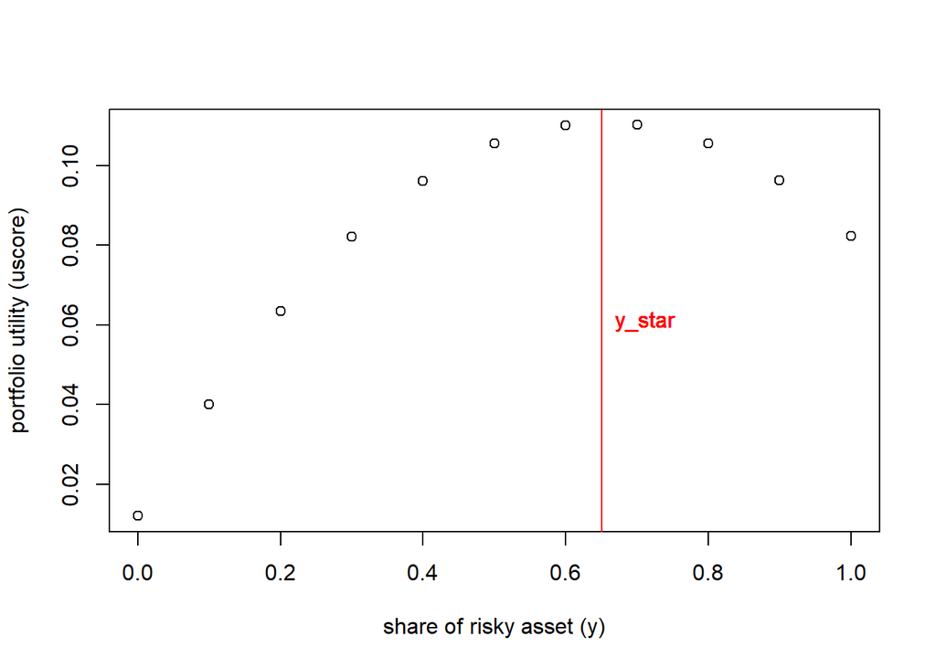

```r
plot(dfutil$y, dfutil$uscore,
     xlab = "share of risky asset (y)",
     ylab = "portfolio utility (uscore)")
abline(v = dfutil$y_star, col = "red")
text(x = dfutil$y_star, y = mean(range(dfutil$uscore)),
     labels = "y_star", col = "red", pos = 4)
```

.

.

## CAL

The optimal `y_star` share of risky assets directly determines the risk and return of our complete portfolio on the CAL.

Recall that we computed the portfolio risk `rsk_port` and return `ret_port` for the utility score. Now, we re-compute these measures with y_star and plot them on the CAL

```r
dfutil = dfutil |>
  mutate(ret_pstar    = rf_exp + y_star*rx_exp) |>
  mutate(rsk_pstar    = y_star^2 * rx_exp^2) |>    # variance
  mutate(rsk_pstar_sd = y_star * rx_sd)            # sd for CAL

View(dfutil)
```

**Warning**

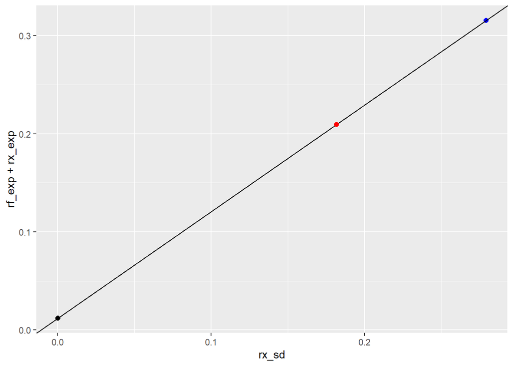

```r
plot_dfcp = ggplot() +
  geom_point(aes(x=rx_sd, y=rf_exp+rx_exp), color = "blue", size = 2) +
  geom_point(aes(x=rf_sd, y=rf_exp), color = "black", size = 2) +
  geom_abline(intercept=rf_exp, slope=sharpe)+
  geom_point(aes(x=dfutil$rsk_pstar_sd, y=dfutil$ret_pstar),
             color = "red", size = 2) +
  labs(x="rx_sd", y="rf_exp + rx_exp")

print(plot_dfcp)
```